# BattleOfNeighbourhood-Copy1

```
                           The Battle of Neighbourhoods- Noida
                                   Alvin philip Cheriyan
                                     07/11/2020
```

## **1 Introduction**

**Noida**, short for **New Okhla Industrial Development Authority**, is a planned city located in Gautam Buddh Nagar district of the Indian state of Uttar Pradesh. It is a satellite city of Delhi and is a part of the National Capital Region of India. As per provisional reports of Census of India, the population of Noida in 2011 was 642,381. The official language of Noida and the one that is most widely spoken is Hindi. With its diverse culture, comes diverse food items. There are many restaurants in Noida, each belonging to different categories like Chinese, Italian, French etc. So as part of this project, we will list and visualise all major parts of Noida.

**Questions that can be asked using the above-mentioned datasets**

- Which places In Noida have some of the finest Restaurants?
- Which Places in Noida have Restaurants with Lowest rating?
- Which place in Noida is suitable for a Foodie?
- Which place in Noida is not suitable for a Foodie?
- What are the best places in Noida for Chinese Restaurant?
- Which places in Noida have highest rated Chinese Restaurants?

## **2 Data**

For this project we need the following data:

- Noida Restaurants data that contains list Locality, Restaurant name, Rating along with their latitude and longitude.
  - Data Source: [zomatoKaggle](https://www.kaggle.com/shrutimehta/zomato-restaurants-data)
  - Description: This data set contains the required information which we will use to explore various localities of Noida city.
- Nearby places in each locality of Noida city.
  - Data Source: [FourSquareAPI](https://developer.foursquare.com)
  - Description: By using this API we will get all the venues in each neighbourhood.

## **3 Approach**

- Collect the Noida city data from [zomatoKaggle](https://www.kaggle.com/shrutimehta/zomato-restaurants-data)
- Using Foursquare API we will find all venues for each neighbourhoods.
- Filter out all venues that are nearby by locality.
- Using aggregative rating for each restaurant to find the best places.
- Visualize the Ranking of neighbourhoods using folium library(python)

```python
import pandas as pd
import numpy as np
import requests # library to handle requests
from pandas.io.json import json_normalize # tranform JSON file into a pandas dataframe
# Matplotlib and associated plotting modules
import matplotlib.cm as cm
import matplotlib.colors as colors
# import k-means from clustering stage
from sklearn.cluster import KMeans

!conda install -c conda-forge folium=0.5.0 --yes
import folium # map rendering library
! pip install geocoder
import geocoder
```

```
Solving environment: ...working... done

# All requested packages already installed.
```

## 3.1 Read the zomato resturant data from csv file

```python
df = pd.read_csv('https://raw.githubusercontent.com/Alvy001/PeerGradedAssignment-Battle-of-Neighbourhood/main/zomato.csv',encoding='ISO-8859-1')
df.head()
```

|  | Restaurant ID | Restaurant Name | Country Code | City | Address | Locality | Locality Verbose | Longitude | Latitude | Cuisines | ... | Currency | Has Table booking | Has Online delivery | Is delivering now | Switch to order menu | Price range | Aggregate rating | Rating color | Rating text | Votes |
| --- | --- | --- | --- | --- | --- | --- | --- | --- | --- | --- | --- | --- | --- | --- | --- | --- | --- | --- | --- | --- | --- |
| 0 | 6317637 | Le Petit Souffle | 162 | Makati City | Third Floor, Century City Mall, Kalayaan Avenu... | Century City Mall, Poblacion, Makati City | Century City Mall, Poblacion, Makati City, Mak... | 121.027535 | 14.565443 | French, Japanese, Desserts | ... | Botswana Pula(P) | Yes | No | No | No | 3 | 4.8 | Dark Green | Excellent | 314 |
| 1 | 6304287 | Izakaya Kikufuji | 162 | Makati City | Little Tokyo, 2277 Chino Roces Avenue, Legaspi... | Little Tokyo, Legaspi Village, Makati City | Little Tokyo, Legaspi Village, Makati City, Ma... | 121.014101 | 14.553708 | Japanese | ... | Botswana Pula(P) | Yes | No | No | No | 3 | 4.5 | Dark Green | Excellent | 591 |
| 2 | 6300002 | Heat - Edsa Shangri-La | 162 | Mandaluyong City | Edsa Shangri-La, 1 Garden Way, Ortigas, Mandal... | Edsa Shangri-La, Ortigas, Mandaluyong City | Edsa Shangri-La, Ortigas, Mandaluyong City, Ma... | 121.056831 | 14.581404 | Seafood, Asian, Filipino, Indian | ... | Botswana Pula(P) | Yes | No | No | No | 4 | 4.4 | Green | Very Good | 270 |
| 3 | 6318506 | Ooma | 162 | Mandaluyong City | Third Floor, Mega Fashion Hall, SM Megamall, O... | SM Megamall, Ortigas, Mandaluyong City | SM Megamall, Ortigas, Mandaluyong City, Mandal... | 121.056475 | 14.585318 | Japanese, Sushi | ... | Botswana Pula(P) | No | No | No | No | 4 | 4.9 | Dark Green | Excellent | 365 |
| 4 | 6314302 | Sambo Kojin | 162 | Mandaluyong City | Third Floor, Mega Atrium, SM Megamall, Ortigas... | SM Megamall, Ortigas, Mandaluyong City | SM Megamall, Ortigas, Mandaluyong City, Mandal... | 121.057508 | 14.584450 | Japanese, Korean | ... | Botswana Pula(P) | Yes | No | No | No | 4 | 4.8 | Dark Green | Excellent | 229 |

5 rows × 21 columns

```python
df_india = df[df['Country Code'] == 1]
df_Nda = df_india[df_india['City'] == 'Noida']
df_Nda.reset_index(drop=True, inplace=True)
df_Nda.head()
```

|  | Restaurant ID | Restaurant Name | Country Code | City | Address | Locality | Locality Verbose | Longitude | Latitude | Cuisines | ... | Currency | Has Table booking | Has Online delivery | Is delivering now | Switch to order menu | Price range | Aggregate rating | Rating color | Rating text | Votes |
| --- | --- | --- | --- | --- | --- | --- | --- | --- | --- | --- | --- | --- | --- | --- | --- | --- | --- | --- | --- | --- | --- |
| 0 | 310063 | Ali Baba Caves | 1 | Noida | 1st Floor, Ansal Plaza Mall, Pari Chowk, Great... | Ansal Plaza Mall, Greater Noida | Ansal Plaza Mall, Greater Noida, Noida | 77.528129 | 28.458107 | Cafe, Chinese | ... | Indian Rupees(Rs.) | No | No | No | No | 2 | 3.1 | Orange | Average | 15 |
| 1 | 312214 | Cafí© Doo Ghoont | 1 | Noida | AG-13, Atrium Floor, Ansal Plaza Mall, Greater... | Ansal Plaza Mall, Greater Noida | Ansal Plaza Mall, Greater Noida, Noida | 77.507456 | 28.463957 | Cafe | ... | Indian Rupees(Rs.) | No | Yes | No | No | 2 | 3.4 | Orange | Average | 50 |
| 2 | 309641 | Knights Chaska | 1 | Noida | 201 to 207, 2nd Floor, Ansal Plaza Mall, Great... | Ansal Plaza Mall, Greater Noida | Ansal Plaza Mall, Greater Noida, Noida | 77.507834 | 28.464434 | North Indian, Chinese | ... | Indian Rupees(Rs.) | Yes | No | No | No | 2 | 2.9 | Orange | Average | 6 |
| 3 | 306688 | Thirsty Scholar Cafe | 1 | Noida | SF-256, 2nd Floor, Ansal Plaza Mall, Near Pari... | Ansal Plaza Mall, Greater Noida | Ansal Plaza Mall, Greater Noida, Noida | 77.507701 | 28.464201 | Cafe | ... | Indian Rupees(Rs.) | No | No | No | No | 1 | 3.2 | Orange | Average | 45 |
| 4 | 18440427 | Savoury Street | 1 | Noida | GF-37, 1st Floor, Ansal Plaza Mall, Greater No... | Ansal Plaza Mall, Greater Noida | Ansal Plaza Mall, Greater Noida, Noida | 77.507701 | 28.464201 | North Indian, Continental, Italian | ... | Indian Rupees(Rs.) | No | No | No | No | 2 | 0.0 | White | Not rated | 3 |

5 rows × 21 columns

## 3.1.1 Data Cleaning

Remove the unwanted columns and rows from dataset

```python
df_Res= df_Nda[df_Nda.Longitude !=0.000000][['Restaurant Name','Locality','Longitude','Latitude','Cuisines','Aggregate rating','Rating text','Votes']]
```

```python
df_Res = df_Res[df_Res['Aggregate rating'] !=0.0]
```

```python
df_Res.head()
```

|  | Restaurant Name | Locality | Longitude | Latitude | Cuisines | Aggregate rating | Rating text | Votes |
| --- | --- | --- | --- | --- | --- | --- | --- | --- |
| 0 | Ali Baba Caves | Ansal Plaza Mall, Greater Noida | 77.528129 | 28.458107 | Cafe, Chinese | 3.1 | Average | 15 |
| 1 | Cafí© Doo Ghoont | Ansal Plaza Mall, Greater Noida | 77.507456 | 28.463957 | Cafe | 3.4 | Average | 50 |
| 2 | Knights Chaska | Ansal Plaza Mall, Greater Noida | 77.507834 | 28.464434 | North Indian, Chinese | 2.9 | Average | 6 |
| 3 | Thirsty Scholar Cafe | Ansal Plaza Mall, Greater Noida | 77.507701 | 28.464201 | Cafe | 3.2 | Average | 45 |
| 5 | JSB Evergreen Snack & Sweets | Brahmaputra Shopping Complex | 77.332577 | 28.569899 | North Indian, Chinese, Fast Food, Street Food | 3.1 | Average | 47 |

## 3.1.2 Creating Map to show the Restaurant clusters

```python
Noida_Rest = folium.Map(location=[28.60, 77.25], zoom_start=12)

X = df_Res['Latitude']
Y = df_Res['Longitude']
Z = np.stack((X, Y), axis=1)

kmeans = KMeans(n_clusters=5, random_state=0).fit(Z)

clusters = kmeans.labels_
colors = ['red', 'green', 'blue', 'yellow','orange']
df_Res ['Cluster'] = clusters

for latitude, longitude, Locality, cluster in zip(df_Res['Latitude'], df_Res['Longitude'], df_Res['Locality'], df_Res['Cluster']):
    label = folium.Popup(Locality, parse_html=True)
    folium.CircleMarker(
        [latitude, longitude],
        radius=5,
        popup=label,
        color='black',
        fill=True,
        fill_color=colors[cluster],
        fill_opacity=0.7).add_to(Noida_Rest)

Noida_Rest
```

Make this Notebook Trusted to load map: File -> Trust Notebook

[interactive chart not shown]

```python
df_Res.head()
```

|  | Restaurant Name | Locality | Longitude | Latitude | Cuisines | Aggregate rating | Rating text | Votes | Cluster |
| --- | --- | --- | --- | --- | --- | --- | --- | --- | --- |
| 0 | Ali Baba Caves | Ansal Plaza Mall, Greater Noida | 77.528129 | 28.458107 | Cafe, Chinese | 3.1 | Average | 15 | 1 |
| 1 | Cafí© Doo Ghoont | Ansal Plaza Mall, Greater Noida | 77.507456 | 28.463957 | Cafe | 3.4 | Average | 50 | 1 |
| 2 | Knights Chaska | Ansal Plaza Mall, Greater Noida | 77.507834 | 28.464434 | North Indian, Chinese | 2.9 | Average | 6 | 1 |
| 3 | Thirsty Scholar Cafe | Ansal Plaza Mall, Greater Noida | 77.507701 | 28.464201 | Cafe | 3.2 | Average | 45 | 1 |
| 5 | JSB Evergreen Snack & Sweets | Brahmaputra Shopping Complex | 77.332577 | 28.569899 | North Indian, Chinese, Fast Food, Street Food | 3.1 | Average | 47 | 0 |

## 3.1.3 Which places In Noida have some of the finest Restaurants?

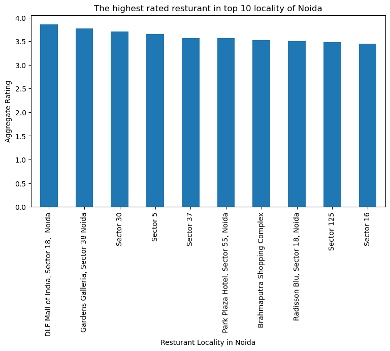

```python
import matplotlib.pyplot as plt
plt.figure(figsize=(9,5), dpi = 100)
# title
plt.title('The highest rated resturant in top 10 locality of Noida')
#On x-axis

#giving a bar plot
df_Res.groupby('Locality')['Aggregate rating'].mean().nlargest(10).plot(kind='bar')

plt.xlabel('Resturant Locality in Noida')
#On y-axis
plt.ylabel('Aggregate Rating')
#displays the plot
plt.show()
```

The best restarants are available in DLF Mall of India, Sector 18, Noida.

## 3.1.4 Which Places in Noida have Restaurants with Lowest rating?

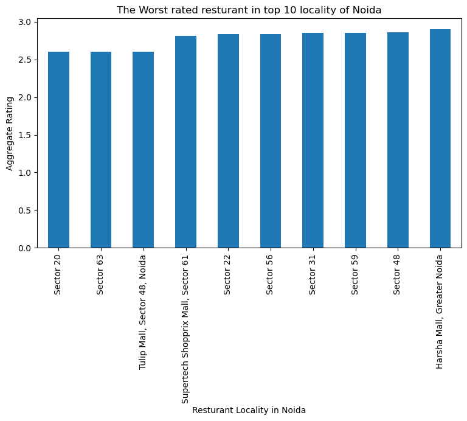

```python
import matplotlib.pyplot as plt
plt.figure(figsize=(9,5), dpi = 100)
# title
plt.title('The Worst rated resturant in top 10 locality of Noida')
#On x-axis

#giving a bar plot

df_Res.groupby('Locality')['Aggregate rating'].mean().nsmallest(10).plot(kind='bar')

plt.xlabel('Resturant Locality in Noida')
#On y-axis
plt.ylabel('Aggregate Rating')

#displays the plot
plt.show()
```

The worst rated Restaurants is in Sector 20.

## 3.1.5 Which place in Noida is suitable for a Foodie?

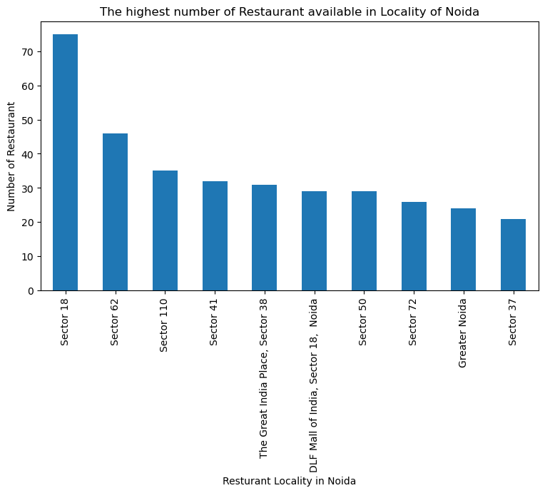

```python
import matplotlib.pyplot as plt
plt.figure(figsize=(9,5), dpi = 100)
# title
plt.title('The highest number of Restaurant available in Locality of Noida')
#On x-axis

#giving a bar plot
df_Res.groupby('Locality')['Restaurant Name'].count().nlargest(10).plot(kind='bar')

plt.xlabel('Resturant Locality in Noida')
#On y-axis
plt.ylabel('Number of Restaurant')

#displays the plot
plt.show()
```

Sector 18 is the best place for Foodie.

## 3.1.6 Which place in Noida is not suitable for a Foodie?

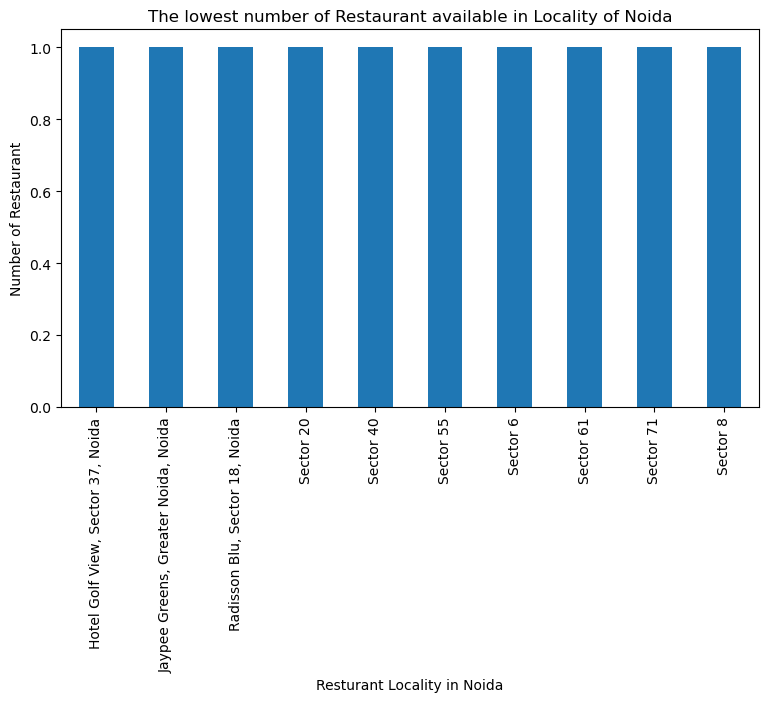

```python
import matplotlib.pyplot as plt
plt.figure(figsize=(9,5), dpi = 100)
# title
plt.title('The lowest number of Restaurant available in Locality of Noida')
#On x-axis

#giving a bar plot
df_Res.groupby('Locality')['Restaurant Name'].count().nsmallest(10).plot(kind='bar')

plt.xlabel('Resturant Locality in Noida')
#On y-axis
plt.ylabel('Number of Restaurant')

#displays the plot
plt.show()
```

No Sector is bad enough for the Foodie as per the above Statistics.

## 3.1.7 What are the best places in Noida for Chinese Restaurant?

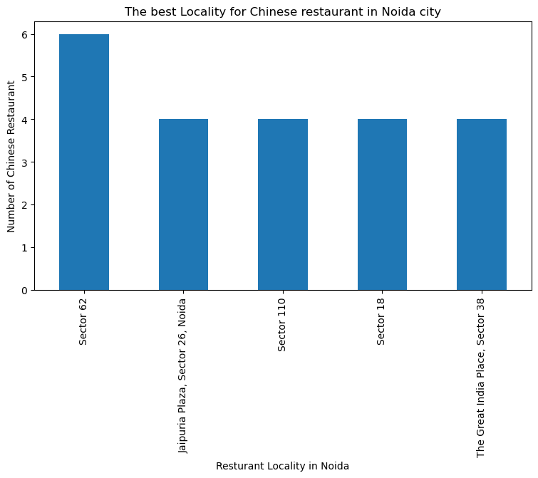

```python
import matplotlib.pyplot as plt
plt.figure(figsize=(9,5), dpi = 100)
# title
plt.title('The best Locality for Chinese restaurant in Noida city')
#On x-axis

#giving a bar plot
df_Res[df_Res['Cuisines'].str.startswith('Chinese')].groupby('Locality')['Restaurant Name'].count().nlargest(5).plot(kind='bar')

plt.xlabel('Resturant Locality in Noida')
#On y-axis
plt.ylabel('Number of Chinese Restaurant')

#displays the plot
plt.show()
```

Sector 62 is the best place for Chinese Restaurant.

## 3.1.8 Which places in Noida have highest rated Chinese Restaurants?

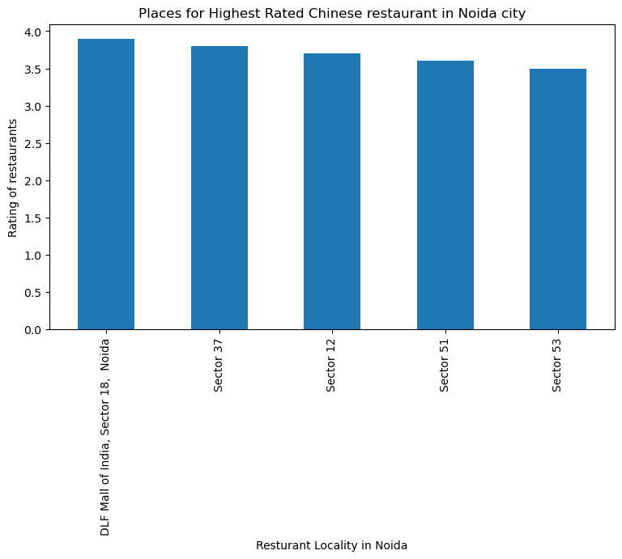

```python
import matplotlib.pyplot as plt
plt.figure(figsize=(9,5), dpi = 100)
# title
plt.title('Places for Highest Rated Chinese restaurant in Noida city')
#On x-axis

#giving a bar plot
df_Res[df_Res['Cuisines'].str.startswith('Chinese')].groupby('Locality')['Aggregate rating'].mean().nlargest(5).plot(kind='bar')

plt.xlabel('Resturant Locality in Noida')
#On y-axis
plt.ylabel('Rating of restaurants')

#displays the plot
plt.show()
```

DLF Mall of India, Sector 18, Noida has best Chinese Resturants.

## 3.2 Data transformation

Based on Locality grouping the data

```python
df_Res_Loc =  df_Res.groupby('Locality').count()['Restaurant Name'].to_frame()
df_Res_rating= df_Res.groupby('Locality')['Aggregate rating'].mean().to_frame()
d_Cuisines = df_Res.groupby(['Locality'])['Cuisines'].agg(', '.join).reset_index()
d_R = df_Res.groupby(['Locality'])['Rating text'].unique().agg(', '.join).reset_index()
d_V = df_Res.groupby(['Locality'])['Votes'].sum().to_frame()
d_Lat = df_Res.groupby('Locality').mean()['Latitude'].to_frame()
d_Lng = df_Res.groupby('Locality').mean()['Longitude'].to_frame()
df_final = pd.merge(d_Lat,d_Lng,on='Locality').merge(df_Res_Loc, on='Locality').merge(d_Cuisines, on='Locality').merge(df_Res_rating,on ='Locality').merge(d_R, on ='Locality').merge(d_V, on ='Locality')
```

```python
df_final = df_final[df_final['Aggregate rating'] != 0.000000]
df_final.columns =['Locality','Lat','Lng', 'No_of_Restaurant','Cusines', 'Agg_Rating','Comments' ,'No_of_Votes']
df_final.head()
```

|  | Locality | Lat | Lng | No_of_Restaurant | Cusines | Agg_Rating | Comments | No_of_Votes |
| --- | --- | --- | --- | --- | --- | --- | --- | --- |
| 0 | Ansal Plaza Mall, Greater Noida | 28.462675 | 77.512780 | 4 | Cafe, Chinese, Cafe, North Indian, Chinese, Cafe | 3.150000 | Average | 116 |
| 1 | Brahmaputra Shopping Complex | 28.570019 | 77.332701 | 4 | North Indian, Chinese, Fast Food, Street Food,... | 3.525000 | Average, Good | 1075 |
| 2 | Centre Stage Mall, Sector 18 | 28.568185 | 77.323030 | 4 | Asian, Continental, Italian, North Indian, Nor... | 3.100000 | Average, Good, Poor | 1247 |
| 3 | DLF Mall of India, Sector 18, Noida | 28.567267 | 77.320868 | 29 | North Indian, Mughlai, North Indian, European,... | 3.858621 | Average, Excellent, Good, Very Good | 8242 |
| 4 | Fortune Inn Grazia, Sector 27, Noida | 28.577435 | 77.328359 | 2 | North Indian, Mughlai, Chinese | 3.300000 | Average | 94 |

```python
df_final.shape
```

```
(77, 8)
```

## 3.2.1 Defining Foursquare Credentials and Version

```python
## Define Foursquare Credentials and Version
CLIENT_ID = 'ZNUQA0Y0JUXEKGWLC2HQAS1HVNDJ4UBDTZIKKUZ40DZH1EL1' # Foursquare ID
CLIENT_SECRET = 'CVQOTVVVTKJACYGLJUY1W2GVZ0UC21YS5S5W0LKOLI1UODKB' # Foursquare Secret
VERSION = '20180604' # Foursquare API version

print('Your credentails:')
print('CLIENT_ID: ' + CLIENT_ID)
print('CLIENT_SECRET:' + CLIENT_SECRET)
```

```
Your credentails:
CLIENT_ID: ZNUQA0Y0JUXEKGWLC2HQAS1HVNDJ4UBDTZIKKUZ40DZH1EL1
CLIENT_SECRET:CVQOTVVVTKJACYGLJUY1W2GVZ0UC21YS5S5W0LKOLI1UODKB
```

## 3.2.2 Function to analyse all localities in Noida in similar way

```python
## create Function to analyse all localities in Noida in similar way

def getNearbyVenues(names, latitudes, longitudes, radius=500,LIMIT = 50):

    venues_list=[]
    for name, lat, lng in zip(names, latitudes, longitudes):
        print(name)

        # create the API request URL
        url = 'https://api.foursquare.com/v2/venues/explore?&client_id={}&client_secret={}&v={}&ll={},{}&radius={}&limit={}'.format(
            CLIENT_ID,
            CLIENT_SECRET,
            VERSION,
            lat,
            lng,
            radius,
            LIMIT)

        # make the GET request
        results = requests.get(url).json()["response"]['groups'][0]['items']

        # return only relevant information for each nearby venue
        venues_list.append([(
            name,
            lat,
            lng,
            v['venue']['name'],
            v['venue']['location']['lat'],
            v['venue']['location']['lng'],
            v['venue']['categories'][0]['name']) for v in results])

    nearby_venues = pd.DataFrame([item for venue_list in venues_list for item in venue_list])
    nearby_venues.columns = ['Locality',
                  'Locality Latitude',
                  'Locality Longitude',
                  'Venue',
                  'Venue Latitude',
                  'Venue Longitude',
                  'Venue Category']

    return(nearby_venues)
```

## 3.2.3 Retrieve venues for Noida Localities

```python
# Retrieve venues for Noida Localities
Noida_venues = getNearbyVenues(names=df_final['Locality'],
                                   latitudes=df_final['Lat'],
                                   longitudes=df_final['Lng']
                                  )
```

```
Ansal Plaza Mall, Greater Noida
Brahmaputra Shopping Complex
Centre Stage Mall, Sector 18
DLF Mall of India, Sector 18,  Noida
Fortune Inn Grazia, Sector 27, Noida
Ganga Shopping Complex, Sector 29
Gardens Galleria, Sector 38 Noida
Greater Noida
Harsha Mall, Greater Noida
Hotel Golf View, Sector 37, Noida
Jaipuria Plaza, Sector 26, Noida
Jaypee Greens Golf & Spa Resort, Surajpur
Jaypee Greens, Greater Noida, Noida
Logix City Centre, Sector 32, Noida
MSX Mall, Greater Noida
Mosaic Hotels, Sector 18, Noida
Park Plaza Hotel, Sector 55, Noida
Radisson Blu, Sector 18, Noida
Sector 10
Sector 11
Sector 110
Sector 12
Sector 125
Sector 132
Sector 15
Sector 16
Sector 18
Sector 19
Sector 2
Sector 20
Sector 21
Sector 22
Sector 25
Sector 26
Sector 27
Sector 28
Sector 29
Sector 3
Sector 30
Sector 31
```

[output cut: 22 more lines]

```
Sector 61
Sector 62
Sector 63
Sector 65
Sector 7
Sector 71
Sector 72
Sector 8
Sector 83
Sector 93
Shopprix Mall, Sector 61, Noida
Spice World Mall, Sector 25
Supertech Shopprix Mall, Sector 61
The Great India Place, Sector 38
Tulip Mall, Sector 48, Noida
```

```python
Noida_venues.head()
```

|  | Locality | Locality Latitude | Locality Longitude | Venue | Venue Latitude | Venue Longitude | Venue Category |
| --- | --- | --- | --- | --- | --- | --- | --- |
| 0 | Ansal Plaza Mall, Greater Noida | 28.462675 | 77.512780 | A Fresh | 28.463620 | 77.511691 | Supermarket |
| 1 | Ansal Plaza Mall, Greater Noida | 28.462675 | 77.512780 | BIKANERVALA | 28.463515 | 77.510857 | Indian Restaurant |
| 2 | Ansal Plaza Mall, Greater Noida | 28.462675 | 77.512780 | Savoy Suites | 28.464374 | 77.509695 | Hotel |
| 3 | Brahmaputra Shopping Complex | 28.570019 | 77.332701 | Brahmaputra Shopping Complex | 28.570067 | 77.332539 | Snack Place |
| 4 | Brahmaputra Shopping Complex | 28.570019 | 77.332701 | Lakshmi Coffee House | 28.570140 | 77.332734 | South Indian Restaurant |

```python
Noida_venues.groupby('Locality').count()
```

| Locality | Locality Latitude | Locality Longitude | Venue | Venue Latitude | Venue Longitude | Venue Category |
| --- | --- | --- | --- | --- | --- | --- |
| Ansal Plaza Mall, Greater Noida | 3 | 3 | 3 | 3 | 3 | 3 |
| Brahmaputra Shopping Complex | 4 | 4 | 4 | 4 | 4 | 4 |
| Centre Stage Mall, Sector 18 | 49 | 49 | 49 | 49 | 49 | 49 |
| DLF Mall of India, Sector 18, Noida | 45 | 45 | 45 | 45 | 45 | 45 |
| Fortune Inn Grazia, Sector 27, Noida | 7 | 7 | 7 | 7 | 7 | 7 |
| ... | ... | ... | ... | ... | ... | ... |
| Shopprix Mall, Sector 61, Noida | 9 | 9 | 9 | 9 | 9 | 9 |
| Spice World Mall, Sector 25 | 9 | 9 | 9 | 9 | 9 | 9 |
| Supertech Shopprix Mall, Sector 61 | 9 | 9 | 9 | 9 | 9 | 9 |
| The Great India Place, Sector 38 | 41 | 41 | 41 | 41 | 41 | 41 |
| Tulip Mall, Sector 48, Noida | 3 | 3 | 3 | 3 | 3 | 3 |

76 rows × 6 columns

```python
print('There are {} uniques categories.'.format(len(Noida_venues['Venue Category'].unique())))
```

```
There are 81 uniques categories.
```

```python
## Analyze Each Locality

# one hot encoding
Noida_onehot = pd.get_dummies(Noida_venues[['Venue Category']], prefix="", prefix_sep="")

# add Locality column back to dataframe
Noida_onehot['Locality'] = Noida_venues['Locality']

# move Locality column to the first column
column_list = Noida_onehot.columns.tolist()
column_number = int(column_list.index('Locality'))
column_list = [column_list[column_number]] + column_list[:column_number] + column_list[column_number+1:]
Noida_onehot = Noida_onehot[column_list]

Noida_onehot.head()
```

|  | Locality | ATM | Arcade | Asian Restaurant | BBQ Joint | Bakery | Bar | Bed & Breakfast | Bistro | Bowling Alley | ... | South Indian Restaurant | Spa | Sporting Goods Shop | Stadium | Supermarket | Taco Place | Tea Room | Theme Park | Train Station | Vegetarian / Vegan Restaurant |
| --- | --- | --- | --- | --- | --- | --- | --- | --- | --- | --- | --- | --- | --- | --- | --- | --- | --- | --- | --- | --- | --- |
| 0 | Ansal Plaza Mall, Greater Noida | 0 | 0 | 0 | 0 | 0 | 0 | 0 | 0 | 0 | ... | 0 | 0 | 0 | 0 | 1 | 0 | 0 | 0 | 0 | 0 |
| 1 | Ansal Plaza Mall, Greater Noida | 0 | 0 | 0 | 0 | 0 | 0 | 0 | 0 | 0 | ... | 0 | 0 | 0 | 0 | 0 | 0 | 0 | 0 | 0 | 0 |
| 2 | Ansal Plaza Mall, Greater Noida | 0 | 0 | 0 | 0 | 0 | 0 | 0 | 0 | 0 | ... | 0 | 0 | 0 | 0 | 0 | 0 | 0 | 0 | 0 | 0 |
| 3 | Brahmaputra Shopping Complex | 0 | 0 | 0 | 0 | 0 | 0 | 0 | 0 | 0 | ... | 0 | 0 | 0 | 0 | 0 | 0 | 0 | 0 | 0 | 0 |
| 4 | Brahmaputra Shopping Complex | 0 | 0 | 0 | 0 | 0 | 0 | 0 | 0 | 0 | ... | 1 | 0 | 0 | 0 | 0 | 0 | 0 | 0 | 0 | 0 |

5 rows × 82 columns

```python
Noida_grouped = Noida_onehot.groupby('Locality').mean().reset_index()
Noida_grouped
```

|  | Locality | ATM | Arcade | Asian Restaurant | BBQ Joint | Bakery | Bar | Bed & Breakfast | Bistro | Bowling Alley | ... | South Indian Restaurant | Spa | Sporting Goods Shop | Stadium | Supermarket | Taco Place | Tea Room | Theme Park | Train Station | Vegetarian / Vegan Restaurant |
| --- | --- | --- | --- | --- | --- | --- | --- | --- | --- | --- | --- | --- | --- | --- | --- | --- | --- | --- | --- | --- | --- |
| 0 | Ansal Plaza Mall, Greater Noida | 0.0 | 0.000000 | 0.000000 | 0.0 | 0.000000 | 0.0 | 0.0 | 0.0 | 0.000000 | ... | 0.00 | 0.0 | 0.000000 | 0.000000 | 0.333333 | 0.000000 | 0.0 | 0.000000 | 0.0 | 0.000000 |
| 1 | Brahmaputra Shopping Complex | 0.0 | 0.000000 | 0.000000 | 0.0 | 0.000000 | 0.0 | 0.0 | 0.0 | 0.000000 | ... | 0.25 | 0.0 | 0.000000 | 0.000000 | 0.000000 | 0.000000 | 0.0 | 0.000000 | 0.0 | 0.000000 |
| 2 | Centre Stage Mall, Sector 18 | 0.0 | 0.020408 | 0.020408 | 0.0 | 0.020408 | 0.0 | 0.0 | 0.0 | 0.020408 | ... | 0.00 | 0.0 | 0.020408 | 0.000000 | 0.000000 | 0.020408 | 0.0 | 0.020408 | 0.0 | 0.000000 |
| 3 | DLF Mall of India, Sector 18, Noida | 0.0 | 0.022222 | 0.000000 | 0.0 | 0.022222 | 0.0 | 0.0 | 0.0 | 0.022222 | ... | 0.00 | 0.0 | 0.022222 | 0.000000 | 0.000000 | 0.022222 | 0.0 | 0.022222 | 0.0 | 0.000000 |
| 4 | Fortune Inn Grazia, Sector 27, Noida | 0.0 | 0.000000 | 0.000000 | 0.0 | 0.142857 | 0.0 | 0.0 | 0.0 | 0.000000 | ... | 0.00 | 0.0 | 0.000000 | 0.000000 | 0.000000 | 0.000000 | 0.0 | 0.000000 | 0.0 | 0.000000 |
| ... | ... | ... | ... | ... | ... | ... | ... | ... | ... | ... | ... | ... | ... | ... | ... | ... | ... | ... | ... | ... | ... |
| 71 | Shopprix Mall, Sector 61, Noida | 0.0 | 0.000000 | 0.000000 | 0.0 | 0.000000 | 0.0 | 0.0 | 0.0 | 0.000000 | ... | 0.00 | 0.0 | 0.000000 | 0.000000 | 0.000000 | 0.000000 | 0.0 | 0.000000 | 0.0 | 0.111111 |
| 72 | Spice World Mall, Sector 25 | 0.0 | 0.000000 | 0.000000 | 0.0 | 0.000000 | 0.0 | 0.0 | 0.0 | 0.000000 | ... | 0.00 | 0.0 | 0.000000 | 0.222222 | 0.000000 | 0.000000 | 0.0 | 0.000000 | 0.0 | 0.000000 |
| 73 | Supertech Shopprix Mall, Sector 61 | 0.0 | 0.000000 | 0.000000 | 0.0 | 0.000000 | 0.0 | 0.0 | 0.0 | 0.000000 | ... | 0.00 | 0.0 | 0.000000 | 0.000000 | 0.000000 | 0.000000 | 0.0 | 0.000000 | 0.0 | 0.111111 |
| 74 | The Great India Place, Sector 38 | 0.0 | 0.024390 | 0.024390 | 0.0 | 0.024390 | 0.0 | 0.0 | 0.0 | 0.024390 | ... | 0.00 | 0.0 | 0.024390 | 0.000000 | 0.000000 | 0.024390 | 0.0 | 0.024390 | 0.0 | 0.000000 |
| 75 | Tulip Mall, Sector 48, Noida | 0.0 | 0.000000 | 0.000000 | 0.0 | 0.333333 | 0.0 | 0.0 | 0.0 | 0.000000 | ... | 0.00 | 0.0 | 0.000000 | 0.000000 | 0.000000 | 0.000000 | 0.0 | 0.000000 | 0.0 | 0.000000 |

76 rows × 82 columns

```python
Noida_grouped.shape
```

```
(76, 82)
```

```python
## print each Locality along with the top 5 most common venues

num_top_venues = 5

for hood in Noida_grouped['Locality']:
    print("----"+hood+"----")
    temp = Noida_grouped[Noida_grouped['Locality'] == hood].T.reset_index()
    temp.columns = ['venue','freq']
    temp = temp.iloc[1:]
    temp['freq'] = temp['freq'].astype(float)
    temp = temp.round({'freq': 2})
    print(temp.sort_values('freq', ascending=False).reset_index(drop=True).head(num_top_venues))
    print('\n')
```

```
----Ansal Plaza Mall, Greater Noida----
               venue  freq
0              Hotel  0.33
1  Indian Restaurant  0.33
2        Supermarket  0.33
3                ATM  0.00
4             Lounge  0.00


----Brahmaputra Shopping Complex----
                     venue  freq
0                Hotel Bar  0.25
1        Indian Restaurant  0.25
2              Snack Place  0.25
3  South Indian Restaurant  0.25
4        Indian Sweet Shop  0.00


----Centre Stage Mall, Sector 18----
                  venue  freq
0     Indian Restaurant  0.16
1           Coffee Shop  0.10
2    Chinese Restaurant  0.10
3           Pizza Place  0.06
4  Fast Food Restaurant  0.06


----DLF Mall of India, Sector 18,  Noida----
                  venue  freq
0                  Café  0.11
1     Indian Restaurant  0.11
2           Coffee Shop  0.09
3           Pizza Place  0.07
4  Fast Food Restaurant  0.07


----Fortune Inn Grazia, Sector 27, Noida----
               venue  freq
0         Food Truck  0.29
1        Pizza Place  0.14
```

[output cut: 627 more lines]

```
                  venue  freq
0     Indian Restaurant  0.12
1           Coffee Shop  0.10
2    Chinese Restaurant  0.10
3  Fast Food Restaurant  0.07
4        Clothing Store  0.07


----Tulip Mall, Sector 48, Noida----
                  venue  freq
0                 Hotel  0.33
1                Bakery  0.33
2  Gym / Fitness Center  0.33
3                   ATM  0.00
4                Lounge  0.00
```

```python
## put that into a pandas dataframe
## First, write a function to sort the venues in descending order.

def return_most_common_venues(row, num_top_venues):
    row_categories = row.iloc[1:]
    row_categories_sorted = row_categories.sort_values(ascending=False)

    return row_categories_sorted.index.values[0:num_top_venues]
```

```python
## create the new dataframe and display the top 10 venues for each Locality.

num_top_venues = 10

indicators = ['st', 'nd', 'rd']

# create columns according to number of top venues
columns = ['Locality']
for ind in np.arange(num_top_venues):
    try:
        columns.append('{}{} Most Common Venue'.format(ind+1, indicators[ind]))
    except:
        columns.append('{}th Most Common Venue'.format(ind+1))

# create a new dataframe
Locality_venues_sorted = pd.DataFrame(columns=columns)
Locality_venues_sorted['Locality'] = Noida_grouped['Locality']

for ind in np.arange(Noida_grouped.shape[0]):
    Locality_venues_sorted.iloc[ind, 1:] = return_most_common_venues(Noida_grouped.iloc[ind, :], num_top_venues)

Locality_venues_sorted
```

|  | Locality | 1st Most Common Venue | 2nd Most Common Venue | 3rd Most Common Venue | 4th Most Common Venue | 5th Most Common Venue | 6th Most Common Venue | 7th Most Common Venue | 8th Most Common Venue | 9th Most Common Venue | 10th Most Common Venue |
| --- | --- | --- | --- | --- | --- | --- | --- | --- | --- | --- | --- |
| 0 | Ansal Plaza Mall, Greater Noida | Hotel | Supermarket | Indian Restaurant | Food Truck | Dessert Shop | Diner | Electronics Store | Fast Food Restaurant | Flea Market | Food |
| 1 | Brahmaputra Shopping Complex | Hotel Bar | Indian Restaurant | South Indian Restaurant | Snack Place | Food Court | Department Store | Dessert Shop | Diner | Electronics Store | Fast Food Restaurant |
| 2 | Centre Stage Mall, Sector 18 | Indian Restaurant | Chinese Restaurant | Coffee Shop | Café | Fast Food Restaurant | Pizza Place | Clothing Store | Multiplex | Shopping Mall | Restaurant |
| 3 | DLF Mall of India, Sector 18, Noida | Café | Indian Restaurant | Coffee Shop | Chinese Restaurant | Fast Food Restaurant | Pizza Place | Clothing Store | Shopping Mall | Restaurant | Movie Theater |
| 4 | Fortune Inn Grazia, Sector 27, Noida | Food Truck | Hotel | Pizza Place | Bakery | Flea Market | Convenience Store | Food Court | Dessert Shop | Diner | Electronics Store |
| ... | ... | ... | ... | ... | ... | ... | ... | ... | ... | ... | ... |
| 71 | Shopprix Mall, Sector 61, Noida | Gym | Pizza Place | Indian Restaurant | Vegetarian / Vegan Restaurant | Chinese Restaurant | Convenience Store | Food | Dessert Shop | Diner | Electronics Store |
| 72 | Spice World Mall, Sector 25 | Stadium | Music Store | Indian Restaurant | Coffee Shop | Market | Electronics Store | Restaurant | Multiplex | Fried Chicken Joint | Food Truck |
| 73 | Supertech Shopprix Mall, Sector 61 | Gym | Pizza Place | Indian Restaurant | Vegetarian / Vegan Restaurant | Chinese Restaurant | Convenience Store | Food | Dessert Shop | Diner | Electronics Store |
| 74 | The Great India Place, Sector 38 | Indian Restaurant | Coffee Shop | Chinese Restaurant | Clothing Store | Café | Fast Food Restaurant | Multiplex | Pizza Place | Shopping Mall | Restaurant |
| 75 | Tulip Mall, Sector 48, Noida | Hotel | Gym / Fitness Center | Bakery | Food Court | Department Store | Dessert Shop | Diner | Electronics Store | Fast Food Restaurant | Flea Market |

76 rows × 11 columns

```python
## Cluster Locality
## Run k-means to cluster the Locality into 5 clusters.

# set number of clusters
kclusters = 5

Noida_clustering = Noida_grouped.drop('Locality', 1)

# run k-means clustering
kmeans = KMeans(n_clusters=kclusters, random_state=0).fit(Noida_clustering)

# check cluster labels generated for each row in the dataframe
kmeans.labels_[0:10]
kmeans.labels_.shape
```

```
(76,)
```

```python
# add clustering labels
Noida_merged = df_final.head(76)
Noida_merged['Cluster Labels'] = kmeans.labels_

# merge Noida_grouped with df_Chinese to add latitude/longitude for each Locality
Noida_merged = Noida_merged.join(Locality_venues_sorted.set_index('Locality'), on='Locality')

Noida_merged.head()
```

|  | Locality | Lat | Lng | No_of_Restaurant | Cusines | Agg_Rating | Comments | No_of_Votes | Cluster Labels | 1st Most Common Venue | 2nd Most Common Venue | 3rd Most Common Venue | 4th Most Common Venue | 5th Most Common Venue | 6th Most Common Venue | 7th Most Common Venue | 8th Most Common Venue | 9th Most Common Venue | 10th Most Common Venue |
| --- | --- | --- | --- | --- | --- | --- | --- | --- | --- | --- | --- | --- | --- | --- | --- | --- | --- | --- | --- |
| 0 | Ansal Plaza Mall, Greater Noida | 28.462675 | 77.512780 | 4 | Cafe, Chinese, Cafe, North Indian, Chinese, Cafe | 3.150000 | Average | 116 | 2 | Hotel | Supermarket | Indian Restaurant | Food Truck | Dessert Shop | Diner | Electronics Store | Fast Food Restaurant | Flea Market | Food |
| 1 | Brahmaputra Shopping Complex | 28.570019 | 77.332701 | 4 | North Indian, Chinese, Fast Food, Street Food,... | 3.525000 | Average, Good | 1075 | 0 | Hotel Bar | Indian Restaurant | South Indian Restaurant | Snack Place | Food Court | Department Store | Dessert Shop | Diner | Electronics Store | Fast Food Restaurant |
| 2 | Centre Stage Mall, Sector 18 | 28.568185 | 77.323030 | 4 | Asian, Continental, Italian, North Indian, Nor... | 3.100000 | Average, Good, Poor | 1247 | 0 | Indian Restaurant | Chinese Restaurant | Coffee Shop | Café | Fast Food Restaurant | Pizza Place | Clothing Store | Multiplex | Shopping Mall | Restaurant |
| 3 | DLF Mall of India, Sector 18, Noida | 28.567267 | 77.320868 | 29 | North Indian, Mughlai, North Indian, European,... | 3.858621 | Average, Excellent, Good, Very Good | 8242 | 0 | Café | Indian Restaurant | Coffee Shop | Chinese Restaurant | Fast Food Restaurant | Pizza Place | Clothing Store | Shopping Mall | Restaurant | Movie Theater |
| 4 | Fortune Inn Grazia, Sector 27, Noida | 28.577435 | 77.328359 | 2 | North Indian, Mughlai, Chinese | 3.300000 | Average | 94 | 0 | Food Truck | Hotel | Pizza Place | Bakery | Flea Market | Convenience Store | Food Court | Dessert Shop | Diner | Electronics Store |

```python
# create final map
map_clusters = folium.Map(location=[latitude, longitude], zoom_start=10)

# set color scheme for the clusters
x = np.arange(kclusters)
ys = [i+x+(i*x)**2 for i in range(kclusters)]
#colors_array = cm.rainbow(np.linspace(0, 1, len(ys)))
#rainbow = [colors.rgb2hex(i) for i in colors_array]
colors = ['red', 'green', 'blue', 'yellow','orange']

# add markers to the map
markers_colors = []
for lat, lon, poi, cluster in zip(Noida_merged['Lat'], Noida_merged['Lng'], Noida_merged['Locality'], Noida_merged['Cluster Labels']):
    label = folium.Popup(str(poi) + ' Cluster ' + str(cluster), parse_html=True)
    folium.CircleMarker(
        [lat, lon],
        radius=5,
        popup=label,
        color='black',
        fill=True,
        fill_color=colors[cluster],
        fill_opacity=0.7).add_to(map_clusters)

map_clusters
```

Make this Notebook Trusted to load map: File -> Trust Notebook

[interactive chart not shown]

```python
## Examine Clusters

## Cluster 1
Noida_merged.loc[Noida_merged['Cluster Labels'] == 0, Noida_merged.columns[[1] + list(range(5, Noida_merged.shape[1]))]]
```

|  | Lat | Agg_Rating | Comments | No_of_Votes | Cluster Labels | 1st Most Common Venue | 2nd Most Common Venue | 3rd Most Common Venue | 4th Most Common Venue | 5th Most Common Venue | 6th Most Common Venue | 7th Most Common Venue | 8th Most Common Venue | 9th Most Common Venue | 10th Most Common Venue |
| --- | --- | --- | --- | --- | --- | --- | --- | --- | --- | --- | --- | --- | --- | --- | --- |
| 1 | 28.570019 | 3.525000 | Average, Good | 1075 | 0 | Hotel Bar | Indian Restaurant | South Indian Restaurant | Snack Place | Food Court | Department Store | Dessert Shop | Diner | Electronics Store | Fast Food Restaurant |
| 2 | 28.568185 | 3.100000 | Average, Good, Poor | 1247 | 0 | Indian Restaurant | Chinese Restaurant | Coffee Shop | Café | Fast Food Restaurant | Pizza Place | Clothing Store | Multiplex | Shopping Mall | Restaurant |
| 3 | 28.567267 | 3.858621 | Average, Excellent, Good, Very Good | 8242 | 0 | Café | Indian Restaurant | Coffee Shop | Chinese Restaurant | Fast Food Restaurant | Pizza Place | Clothing Store | Shopping Mall | Restaurant | Movie Theater |
| 4 | 28.577435 | 3.300000 | Average | 94 | 0 | Food Truck | Hotel | Pizza Place | Bakery | Flea Market | Convenience Store | Food Court | Dessert Shop | Diner | Electronics Store |
| 5 | 28.567820 | 3.214286 | Average, Good | 747 | 0 | Metro Station | Bakery | Café | Bistro | South Indian Restaurant | Snack Place | Indian Restaurant | Pizza Place | Flea Market | Bus Station |
| ... | ... | ... | ... | ... | ... | ... | ... | ... | ... | ... | ... | ... | ... | ... | ... |
| 70 | 28.528872 | 3.200000 | Average | 15 | 0 | Gym / Fitness Center | Vegetarian / Vegan Restaurant | Food Court | Department Store | Dessert Shop | Diner | Electronics Store | Fast Food Restaurant | Flea Market | Food |
| 71 | 28.518748 | 3.125000 | Average, Good, Poor | 561 | 0 | Coffee Shop | Ice Cream Shop | Golf Course | Plaza | Café | Food | Department Store | Dessert Shop | Diner | Electronics Store |
| 72 | 28.595794 | 3.100000 | Average | 8 | 0 | Gym | Pizza Place | Indian Restaurant | Vegetarian / Vegan Restaurant | Chinese Restaurant | Convenience Store | Food | Dessert Shop | Diner | Electronics Store |
| 73 | 28.585808 | 3.050000 | Average, Good, Poor | 1959 | 0 | Stadium | Music Store | Indian Restaurant | Coffee Shop | Market | Electronics Store | Restaurant | Multiplex | Fried Chicken Joint | Food Truck |
| 74 | 28.597117 | 2.811765 | Average, Good, Poor | 1392 | 0 | Gym | Pizza Place | Indian Restaurant | Vegetarian / Vegan Restaurant | Chinese Restaurant | Convenience Store | Food | Dessert Shop | Diner | Electronics Store |

67 rows × 15 columns

```python
## Examine Clusters

## Cluster 2
Noida_merged.loc[Noida_merged['Cluster Labels'] == 1, Noida_merged.columns[[1] + list(range(5, Noida_merged.shape[1]))]]
```

|  | Lat | Agg_Rating | Comments | No_of_Votes | Cluster Labels | 1st Most Common Venue | 2nd Most Common Venue | 3rd Most Common Venue | 4th Most Common Venue | 5th Most Common Venue | 6th Most Common Venue | 7th Most Common Venue | 8th Most Common Venue | 9th Most Common Venue | 10th Most Common Venue |
| --- | --- | --- | --- | --- | --- | --- | --- | --- | --- | --- | --- | --- | --- | --- | --- |
| 39 | 28.577396 | 2.850000 | Average | 61 | 1 | Multiplex | Convenience Store | Department Store | Dessert Shop | Diner | Electronics Store | Fast Food Restaurant | Flea Market | Food | Food Court |
| 47 | 28.558628 | 3.141667 | Average, Good | 663 | 1 | Convenience Store | Hotel | Department Store | Dessert Shop | Diner | Electronics Store | Fast Food Restaurant | Flea Market | Food | Food Court |

```python
## Examine Clusters

## Cluster 3
Noida_merged.loc[Noida_merged['Cluster Labels'] == 2, Noida_merged.columns[[1] + list(range(5, Noida_merged.shape[1]))]]
```

|  | Lat | Agg_Rating | Comments | No_of_Votes | Cluster Labels | 1st Most Common Venue | 2nd Most Common Venue | 3rd Most Common Venue | 4th Most Common Venue | 5th Most Common Venue | 6th Most Common Venue | 7th Most Common Venue | 8th Most Common Venue | 9th Most Common Venue | 10th Most Common Venue |
| --- | --- | --- | --- | --- | --- | --- | --- | --- | --- | --- | --- | --- | --- | --- | --- |
| 0 | 28.462675 | 3.150000 | Average | 116 | 2 | Hotel | Supermarket | Indian Restaurant | Food Truck | Dessert Shop | Diner | Electronics Store | Fast Food Restaurant | Flea Market | Food |
| 16 | 28.603867 | 3.566667 | Average, Very Good | 285 | 2 | Hotel | Indian Restaurant | Food Truck | Department Store | Dessert Shop | Diner | Electronics Store | Fast Food Restaurant | Flea Market | Food |
| 64 | 28.621141 | 2.600000 | Average | 15 | 2 | Fast Food Restaurant | Vegetarian / Vegan Restaurant | Hotel | Department Store | Dessert Shop | Diner | Electronics Store | Flea Market | Food | Food Court |

```python
## Examine Clusters

## Cluster 4
Noida_merged.loc[Noida_merged['Cluster Labels'] ==3 , Noida_merged.columns[[1] + list(range(5, Noida_merged.shape[1]))]]
```

|  | Lat | Agg_Rating | Comments | No_of_Votes | Cluster Labels | 1st Most Common Venue | 2nd Most Common Venue | 3rd Most Common Venue | 4th Most Common Venue | 5th Most Common Venue | 6th Most Common Venue | 7th Most Common Venue | 8th Most Common Venue | 9th Most Common Venue | 10th Most Common Venue |
| --- | --- | --- | --- | --- | --- | --- | --- | --- | --- | --- | --- | --- | --- | --- | --- |
| 63 | 28.616566 | 3.041304 | Average, Good, Poor | 2512 | 3 | Sandwich Place | Multiplex | Coffee Shop | Department Store | Café | Food Truck | Breakfast Spot | Food | Dessert Shop | Diner |

```python
## Examine Clusters

## Cluster 5
Noida_merged.loc[Noida_merged['Cluster Labels'] == 4, Noida_merged.columns[[1] + list(range(5, Noida_merged.shape[1]))]]
```

|  | Lat | Agg_Rating | Comments | No_of_Votes | Cluster Labels | 1st Most Common Venue | 2nd Most Common Venue | 3rd Most Common Venue | 4th Most Common Venue | 5th Most Common Venue | 6th Most Common Venue | 7th Most Common Venue | 8th Most Common Venue | 9th Most Common Venue | 10th Most Common Venue |
| --- | --- | --- | --- | --- | --- | --- | --- | --- | --- | --- | --- | --- | --- | --- | --- |
| 49 | 28.553746 | 3.200000 | Average | 29 | 4 | Hotel | Gym / Fitness Center | Bakery | Food Court | Department Store | Dessert Shop | Diner | Electronics Store | Fast Food Restaurant | Flea Market |
| 69 | 28.596372 | 3.200000 | Average | 9 | 4 | Food Truck | Bed & Breakfast | Vegetarian / Vegan Restaurant | Dessert Shop | Diner | Electronics Store | Fast Food Restaurant | Flea Market | Food | Food Court |
| 75 | 28.567462 | 3.158065 | Average, Good, Poor, Very Good | 6377 | 4 | Indian Restaurant | Coffee Shop | Chinese Restaurant | Clothing Store | Café | Fast Food Restaurant | Multiplex | Pizza Place | Shopping Mall | Restaurant |